# NLP-Assignment2

### Group:

Aniketh Satyanarayana, Shilpi Kumari, Swetha Vijaya Raju, Yong Zhao

```python
from nltk.book import *
```

```
*** Introductory Examples for the NLTK Book ***
Loading text1, ..., text9 and sent1, ..., sent9
Type the name of the text or sentence to view it.
Type: 'texts()' or 'sents()' to list the materials.
text1: Moby Dick by Herman Melville 1851
text2: Sense and Sensibility by Jane Austen 1811
text3: The Book of Genesis
text4: Inaugural Address Corpus
text5: Chat Corpus
text6: Monty Python and the Holy Grail
text7: Wall Street Journal
text8: Personals Corpus
text9: The Man Who Was Thursday by G . K . Chesterton 1908
```

#### 1. Try using the Python interpreter as a calculator, and typing expressions like 12 / (4 + 1).

```python
12 / (4 + 1)
```

```
2.4
```

#### 2. Given an alphabet of 26 letters, there are 26 to the power 10, or 26 ** 10, ten-letter strings we can form. That works out to 141167095653376. How many hundred-letter strings are possible?

```python
26**100
```

```
3142930641582938830174357788501626427282669988762475256374173175398995908420104023465432599069702289330964075081611719197835869803511992549376
```

#### 3. The Python multiplication operation can be applied to lists. What happens when you type ['Monty', 'Python'] *20, or 3* sent1?

```python
['Monty', 'Python'] * 20
```

```
['Monty',
 'Python',
 'Monty',
 'Python',
 'Monty',
 'Python',
 'Monty',
 'Python',
 'Monty',
 'Python',
 'Monty',
 'Python',
 'Monty',
 'Python',
 'Monty',
 'Python',
 'Monty',
 'Python',
 'Monty',
 'Python',
 'Monty',
 'Python',
 'Monty',
 'Python',
 'Monty',
 'Python',
 'Monty',
 'Python',
 'Monty',
 'Python',
 'Monty',
 'Python',
 'Monty',
 'Python',
 'Monty',
 'Python',
 'Monty',
 'Python',
 'Monty',
 'Python']
```

```python
3 * sent1
```

```
['Call',
 'me',
 'Ishmael',
 '.',
 'Call',
 'me',
 'Ishmael',
 '.',
 'Call',
 'me',
 'Ishmael',
 '.']
```

#### 4. Review 1 on computing with language. How many words are there in text2? How many distinct words are there?

```python
print("There are %d words in text2." %(len(text2)))
```

```
There are 141576 words in text2.
```

```python
print("There are %d distinct words in text2." %(len(set(text2))))
```

```
There are 6833 distinct words in text2.
```

#### 5. Compare the lexical diversity scores for humor and romance fiction in 1.1. Which genre is more lexically diverse?

- In table 1.1, humor has a lexical diversity of 0.231.
- Romance fiction has a lexical diversity of 0.121.
- So, humor is more lexically diverse than romance fiction.

```python
def lexical_diversity(text):
    return len(set(text)) / len(text)
```

#### Romance

```python
text2
```

```
<Text: Sense and Sensibility by Jane Austen 1811>
```

```python
lexical_diversity(text2)
```

```
0.04826383002768831
```

#### Humor

```python
text6
```

```
<Text: Monty Python and the Holy Grail>
```

```python
lexical_diversity(text6)
```

```
0.1276595744680851
```

#### 6. Produce a dispersion plot of the four main protagonists in Sense and Sensibility: Elinor, Marianne, Edward, and Willoughby. What can you observe about the different roles played by the males and females in this novel? Can you identify the couples?

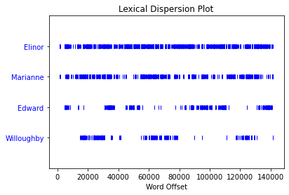

```python
text2.dispersion_plot(["Elinor", "Marianne", "Edward", "Willoughby"])
```

The female characters in the novel are mentioned consistently throughout the whole text shown by their abundance of stripes in the dispersion plot, while the male characters are mentioned generally less throughout the text. The couples are either Elinor/Edward and Marianne/Willoughby, or Elinor/Willoughby and Marianne/Edward as Edward and Willoughby rarely are mentioned at the same time (thus, they cannot be a couple).

#### 7. Find the collocations in text5.

```python
text5.collocations()
```

```
wanna chat; PART JOIN; MODE #14-19teens; JOIN PART; PART PART;
cute.-ass MP3; MP3 player; JOIN JOIN; times .. .; ACTION watches; guys
wanna; song lasts; last night; ACTION sits; -...)...- S.M.R.; Lime
Player; Player 12%; dont know; lez gurls; long time
```

#### 8. Consider the following Python expression: len(set(text4)). State the purpose of this expression. Describe the two steps involved in performing this computation.

```python
type(text4)
```

```
nltk.text.Text
```

```python
len(text4)
```

```
152901
```

```python
len(set(text4))
```

```
10025
```

The function len() counts the number of tokens in the text including words and punctuation symbols. The function set() takes the vocabulary of a text or the set of tokens that the text uses by collapsing all duplicates together.

#### 9. Review 2 on lists and strings.

a. Define a string and assign it to a variable, e.g., my_string = 'My String' (but put something more interesting in the string). Print the contents of this variable in two ways, first by simply typing the variable name and pressing enter, then by using the print statement.

```python
string = 'Put something more interesting here'

#Print using variable name & enter
string
```

```
'Put something more interesting here'
```

```python
# Print using print statement
print(string)
```

```
Put something more interesting here
```

b. Try adding the string to itself using my_string + my_string, or multiplying it by a number, e.g., my_string * 3. Notice that the strings are joined together without any spaces. How could you fix this?

```python
string + string
```

```
'Put something more interesting herePut something more interesting here'
```

```python
# Fixed
string + " " + string
```

```
'Put something more interesting here Put something more interesting here'
```

```python
string * 3
```

```
'Put something more interesting herePut something more interesting herePut something more interesting here'
```

```python
# Fixed
string = " Put something more interesting here"
(string * 3).strip()
```

```
'Put something more interesting here Put something more interesting here Put something more interesting here'
```

#### 10. Define a variable my_sent to be a list of words, using the syntax my_sent = ["My", "sent"] (but with your own words, or a favorite saying).

a. Use ' '.join(my_sent) to convert this into a string.

```python
my_sent = ["This","is","my","favorite","saying."]
```

```python
my_sent_string = " ".join(my_sent)
my_sent_string
```

```
'This is my favorite saying.'
```

b. Use split() to split the string back into the list form you had to start with.

```python
my_sent_split = my_sent_string.split()
my_sent_split
```

```
['This', 'is', 'my', 'favorite', 'saying.']
```

#### 11. Define several variables containing lists of words, e.g., phrase1, phrase2, and so on. Join them together in various combinations (using the plus operator) to form whole sentences. What is the relationship between len(phrase1 + phrase2) and len(phrase1) + len(phrase2)?

```python
phrase1 = ["This","is","a","list","of","words."]
phrase2 = ["Another","day","in","paradise."]
phrase3 = ["Natural","language","processing."]
```

```python
phrase1 + phrase2 + phrase3
```

```
['This',
 'is',
 'a',
 'list',
 'of',
 'words.',
 'Another',
 'day',
 'in',
 'paradise.',
 'Natural',
 'language',
 'processing.']
```

```python
len(phrase1 + phrase2) == len(phrase1) + len(phrase2)
```

```
True
```

The relationship between len(phrase1 + phrase2) and len(phrase1) + len(phrase2) is the same.

#### 12. Consider the following two expressions, which have the same value. Which one will typically be more relevant in NLP? Why?

"Monty Python"[6:12] ["Monty", "Python"][1]

```python
a = "Monty Python"[6:12]
a
```

```
'Python'
```

```python
b = ["Monty","Python"][1]
b
```

```
'Python'
```

The second one is more relevant in NLP because when we have a list of words, it makes it easier to index based on words so that we can easily extract specific words or punctations.

#### 13. We have seen how to represent a sentence as a list of words, where each word is a sequence of characters. What does sent1[2][2] do? Why? Experiment with other index values.

```python
sent1[2][2]
```

```
'h'
```

sent1[2][2] takes the 3rd item from the list which is the word Ishmael (index 2) and returns the 3rd character from the word which is the letter 'h' (2nd indexed character).

```python
# Experimenting
sent1[0][0:3]
```

```
'Cal'
```

#### 14. The first sentence of text3 is provided to you in the variable sent3. The index of the in sent3 is 1, because sent3[1] gives us 'the'. What are the indexes of the two other occurrences of this word in sent3?

```python
print(sent3, end = ' ')
```

```
['In', 'the', 'beginning', 'God', 'created', 'the', 'heaven', 'and', 'the', 'earth', '.']
```

```python
[i for i in range(len(sent3)) if sent3[i] == 'the']
```

```
[1, 5, 8]
```

The word 'the' occurs at Index 5 and Index 8.

#### 15. Review the discussion of conditionals in 4. Find all words in the Chat Corpus (text5) starting with the letter b. Show them in alphabetical order.

```python
sorted(w for w in set(text5) if w.startswith("b"))
```

```
['b',
 'b-day',
 'b/c',
 'b4',
 'babay',
 'babble',
 'babblein',
 'babe',
 'babes',
 'babi',
 'babies',
 'babiess',
 'baby',
 'babycakeses',
 'bachelorette',
 'back',
 'backatchya',
 'backfrontsidewaysandallaroundtheworld',
 'backroom',
 'backup',
 'bacl',
 'bad',
 'bag',
 'bagel',
 'bagels',
 'bahahahaa',
 'bak',
 'baked',
 'balad',
 'balance',
 'balck',
 'ball',
 'ballin',
 'balls',
 'ban',
 'band',
 'bandito',
 'bandsaw',
 'banjoes',
 'banned',
```

[output cut: 253 more lines]

```
 'butter',
 'butterscotch',
 'button',
 'buttons',
 'buy',
 'buying',
 'bwahahahahahahahahahaha',
 'by',
 'byb',
 'bye',
 'byeee',
 'byeeee',
 'byeeeeeeee',
 'byeeeeeeeeeeeee',
 'byes']
```

#### 16. Type the expression list(range(10)) at the interpreter prompt. Now try list(range(10, 20)), list(range(10, 20, 2)), and list(range(20, 10, -2)). We will see a variety of uses for this built-in function in later chapters.

```python
list(range(10))
```

```
[0, 1, 2, 3, 4, 5, 6, 7, 8, 9]
```

```python
list(range(10,20))
```

```
[10, 11, 12, 13, 14, 15, 16, 17, 18, 19]
```

```python
list(range(10, 20, 2))
```

```
[10, 12, 14, 16, 18]
```

```python
list(range(20, 10, -2))
```

```
[20, 18, 16, 14, 12]
```

#### 17. Use text9.index() to find the index of the word sunset. You'll need to insert this word as an argument between the parentheses. By a process of trial and error, find the slice for the complete sentence that contains this word.

```python
text9.index("sunset")
```

```
629
```

```python
text9[621 : 644]
```

```
['THE',
 'suburb',
 'of',
 'Saffron',
 'Park',
 'lay',
 'on',
 'the',
 'sunset',
 'side',
 'of',
 'London',
 ',',
 'as',
 'red',
 'and',
 'ragged',
 'as',
 'a',
 'cloud',
 'of',
 'sunset',
 '.']
```

with a for-loop and a conditional that could be generalized for other sentences:

```python
full_sent = ""
alpha_text = []

for i in range(613, 644):

    if text9[i].isalpha():
        alpha_text.append(text9[i])
    else:
        full_sent += (' '.join(alpha_text) + text9[i] + ' ')
        alpha_text = []

print(full_sent)
```

```
CHAPTER I THE TWO POETS OF SAFFRON PARK THE suburb of Saffron Park lay on the sunset side of London, as red and ragged as a cloud of sunset.
```

#### 18. Using list addition, and the set and sorted operations, compute the vocabulary of the sentences sent1 ... sent8.

```python
sorted_set = sorted(set(sent1 + sent2 + sent3 + sent4 + sent5 + sent6 + sent7 + sent8))
sorted_set[:10]
```

```
['!', ',', '-', '.', '1', '25', '29', '61', ':', 'ARTHUR']
```

```python
# if we should only include alphabet characters and ignore cases.
alpha_set = set([t.lower() for t in sorted_set if t.isalpha()])
print(alpha_set)
```

```
{'clop', 'dashwood', 'citizens', 'pierre', 'join', 'of', 'problem', 'encounters', 'whoa', 'for', 'board', 'been', 'will', 'arthur', 'male', 'director', 'had', 'as', 'vinken', 'call', 'family', 'there', 'nonexecutive', 'and', 'with', 'god', 'seeks', 'settled', 'years', 'in', 'scene', 'discreet', 'sen…
```

```python
len(alpha_set)
```

```
60
```

#### 19. What is the difference between the following two lines? Which one will give a larger value? Will this be the case for other texts?

- sorted(set(w.lower() for w in text1))
- sorted(w.lower() for w in set(text1))

```python
len(sorted(set(w.lower() for w in text1)))
```

```
17231
```

```python
len(sorted(w.lower() for w in set(text1)))
```

```
19317
```

the second one will give a larger value. Because it firstly execute set(text1), which contains same word in different case. Consiquently the final list will include duplicate words. While the first one will execute set() just before sorting, so it won't include duplications.

#### 20. What is the difference between the following two tests: w.isupper() and not w.islower()?

Being upper case doesn't equal to not being lower case. w can contain both capital letters and lower case letters, and even other elements that are not alphabet character. In this both w.isupper() and w.islower() will return False, but 'not w.islower()' will return True.

- w.isupper() returns True when every character in w is upper case.
- not w.islower() returns True when there is a character in w which is not upper case.

```python
'Hello'.isupper()
```

```
False
```

```python
not 'Hello'.islower()
```

```
True
```

#### 21. Write the slice expression that extracts the last two words of text2.

```python
text2[-2:]
```

```
['THE', 'END']
```

#### 22. Find all the four-letter words in the Chat Corpus (text5). With the help of a frequency distribution (FreqDist), show these words in decreasing order of frequency.

```python
# If we do not include values with symbols, the four-letter words in text 5 would be:
fdist = FreqDist(w.lower() for w in text5)
lst_fdist = fdist.most_common()
res = [w for w in lst_fdist if w[0].isalpha() and len(w[0]) == 4]#not sure if numbers should be included
print(res)
```

```
[('part', 1022), ('join', 1021), ('that', 284), ('what', 201), ('here', 185), ('have', 171), ('like', 160), ('with', 154), ('chat', 146), ('your', 142), ('good', 132), ('lmao', 128), ('just', 128), ('know', 104), ('room', 103), ('this', 98), ('from', 96), ('well', 91), ('yeah', 85), ('hiya', 85), ('…
```

#### 23. Review the discussion of looping with conditions in 4. Use a combination of for and if statements to loop over the words of the movie script for Monty Python and the Holy Grail (text6) and print all the uppercase words, one per line.

```python
for token in text6:
    if token.isupper():
        print(token)
```

```
SCENE
KING
ARTHUR
SOLDIER
ARTHUR
I
SOLDIER
ARTHUR
I
I
SOLDIER
ARTHUR
SOLDIER
ARTHUR
SOLDIER
ARTHUR
SOLDIER
ARTHUR
SOLDIER
ARTHUR
SOLDIER
ARTHUR
SOLDIER
ARTHUR
SOLDIER
A
ARTHUR
SOLDIER
A
ARTHUR
SOLDIER
ARTHUR
SOLDIER
I
ARTHUR
I
SOLDIER
SOLDIER
SOLDIER
I
```

[output cut: 1717 more lines]

```
BEDEVERE
INSPECTOR
OFFICER
INSPECTOR
OFFICER
OFFICER
RANDOM
RANDOM
OFFICER
OFFICER
OFFICER
OFFICER
INSPECTOR
OFFICER
CAMERAMAN
```

```python
#if only want to print one time per word
for token in set(text6):
    if token.isupper():
        print(token)
```

```
GOD
OLD
GUESTS
WINSTON
AMAZING
ENCHANTER
MINSTREL
BORS
PRINCE
LEFT
BLACK
DEAD
LUCKY
MASTER
CART
U
MAN
VILLAGER
Y
NARRATOR
MONKS
DIRECTOR
CROWD
ARMY
PRINCESS
S
CHARACTERS
ZOOT
B
CRONE
GUEST
HEADS
RANDOM
CHARACTER
SOLDIER
BRIDE
PIGLET
HEAD
I
FRENCH
```

[output cut: 46 more lines]

```
ROBIN
BROTHER
PRISONER
FATHER
CUSTOMER
KNIGHTS
ALL
WIFE
SECOND
PERSON
THE
C
ANIMATOR
SIR
ARTHUR
```

#### 24. Write expressions for finding all words in text6 that meet the conditions listed below. The result should be in the form of a list of words: ['word1', 'word2', ...].

a. Ending in ise

```python
sorted(w for w in set(text6) if w.endswith("ise"))
```

```
['apologise', 'noise', 'surprise', 'wise']
```

b. Containing the letter z

```python
sorted(w for w in set(text6) if "z" in w)
```

```
['Fetchez', 'amazes', 'frozen', 'zhiv', 'zone', 'zoo', 'zoop', 'zoosh']
```

c. Containing the sequence of letters pt

```python
sorted(w for w in set(text6) if "pt" in w)
```

```
['Chapter',
 'Thpppppt',
 'Thppppt',
 'Thpppt',
 'Thppt',
 'aptly',
 'empty',
 'excepting',
 'ptoo',
 'temptation',
 'temptress']
```

d. Having all lowercase letters except for an initial capital (i.e., titlecase)

```python
sorted(word for word in set(text6) if word.istitle())
```

```
['A',
 'Aaaaaaaaah',
 'Aaaaaaaah',
 'Aaaaaah',
 'Aaaah',
 'Aaaaugh',
 'Aaagh',
 'Aaah',
 'Aaauggh',
 'Aaaugh',
 'Aaauugh',
 'Aagh',
 'Aah',
 'Aauuggghhh',
 'Aauuugh',
 'Aauuuuugh',
 'Aauuuves',
 'Action',
 'Actually',
 'African',
 'Ages',
 'Aggh',
 'Agh',
 'Ah',
 'Ahh',
 'Alice',
 'All',
 'Allo',
 'Almighty',
 'Alright',
 'Am',
 'Amen',
 'An',
 'Anarcho',
 'And',
 'Angnor',
 'Anthrax',
 'Antioch',
 'Anybody',
 'Anyway',
```

[output cut: 416 more lines]

```
 'With',
 'Woa',
 'Wood',
 'Would',
 'Y',
 'Yapping',
 'Yay',
 'Yeaaah',
 'Yeaah',
 'Yeah',
 'Yes',
 'You',
 'Your',
 'Yup',
 'Zoot']
```

#### 25. Define sent to be the list of words ['she', 'sells', 'sea', 'shells', 'by', 'the', 'sea', 'shore']. Now write code to perform the following tasks:

- Print all words beginning with sh
- Print all words longer than four characters

```python
list = ['she', 'sells', 'sea', 'shells', 'by', 'the', 'sea', 'shore']
```

```python
sorted(w for w in list if w.startswith("sh"))
```

```
['she', 'shells', 'shore']
```

```python
sorted(w for w in list if len(w) > 4)
```

```
['sells', 'shells', 'shore']
```

#### 26. What does the following Python code do? sum(len(w) for w in text1) Can you use it to work out the average word length of a text?

```python
sum_length = sum(len(w) for w in text1)
sum_length
```

```
999044
```

This function sums up the length of every word in the text.

```python
# Finding average
average_length = sum_length/len(text1)
average_length
```

```
3.830411128023649
```

#### 27. Define a function called vocab_size(text) that has a single parameter for the text, and which returns the vocabulary size of the text.

```python
def vocab_size(text):
    return len(set(w.lower() for w in text if w.isalpha()))
vocab_size(text1)
```

```
16948
```

#### 28. Define a function percent(word, text) that calculates how often a given word occurs in a text, and expresses the result as a percentage.

```python
def percent(word,text):
    occurence = text.count(word)
    length = len(text)
    result = 100 * (occurence/length)
    return str(result) + '%'
```

```python
percent('the',text2)
```

```
'2.7271571452788606%'
```

#### 29. We have been using sets to store vocabularies. Try the following Python expression: set(sent3) < set(text1). Experiment with this using different arguments to set(). What does it do? Can you think of a practical application for this?

```python
sent3
```

```
['In',
 'the',
 'beginning',
 'God',
 'created',
 'the',
 'heaven',
 'and',
 'the',
 'earth',
 '.']
```

```python
set(sent3) < set(text1)
```

```
True
```

```python
set(sent1) > set(text2)
```

```
False
```

```python
set(text2) > set(text1)
```

```
False
```

```python
set(sent1) < set(sent5)
```

```
False
```

This function could be used to determine if one set was drawn from another, i.e., to try to locate which text a sentence was taken from. However, this would generate a large number of false positives if the sentence was sufficiently short, as shown above. It could also be used to compare the similarities between two texts - with the condition that one text would have to be significantly shorter than the other.